# What Dr. Vardeman is worried about: Trusted cognitive Agents

Charles F Vardeman II

2023-08-21

## Motivation: Tatical ammunition management Micro Services (TAMMS)

[figure not shown]

## Motivation: TAMMS cognitive Agents

[figure not shown]

## Motivation: TAMMS KG

[figure not shown]

## Cognitive Agents based on LLMs

[figure not shown]

[Joon Sung Park, Joseph C. O’Brien, Carrie J. Cai, Meredith Ringel Morris, Percy Liang, and Michael S. Bernstein. “Generative Agents: Interactive Simulacra of Human Behavior.” arXiv, August 5, 2023. http://arxiv.org/abs/2304.03442.](http://arxiv.org/abs/2304.03442)

## Cognitive Agents based on LLMs Architecture

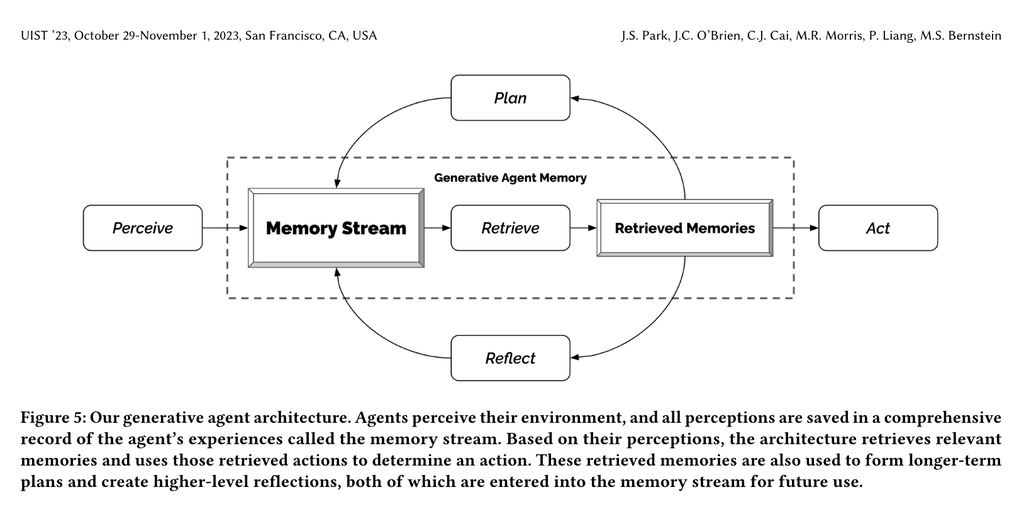

[Joon Sung Park, Joseph C. O’Brien, Carrie J. Cai, Meredith Ringel Morris, Percy Liang, and Michael S. Bernstein. “Generative Agents: Interactive Simulacra of Human Behavior.” arXiv, August 5, 2023. http://arxiv.org/abs/2304.03442.](http://arxiv.org/abs/2304.03442)

## Cognitive Agents based on LLMs Architecture Framework

[figure not shown]

[Park, Joon Sung. “Generative Agents: Interactive Simulacra of Human Behavior,” August 22, 2023. https://github.com/joonspk-research/generative_agents.](https://github.com/joonspk-research/generative_agents)

## Activity Specific Agents: Web Agents

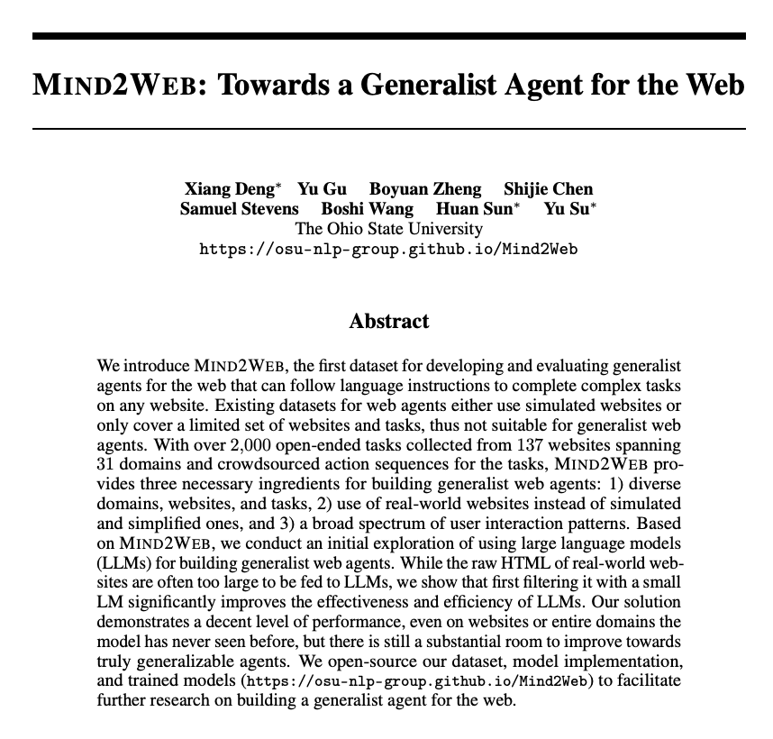

[Deng, Xiang, Yu Gu, Boyuan Zheng, Shijie Chen, Samuel Stevens, Boshi Wang, Huan Sun, and Yu Su. “Mind2Web: Towards a Generalist Agent for the Web.” arXiv, June 14, 2023. http://arxiv.org/abs/2306.06070.](http://arxiv.org/abs/2306.06070)

## Activity Specific Agents: Web Agents Architecture

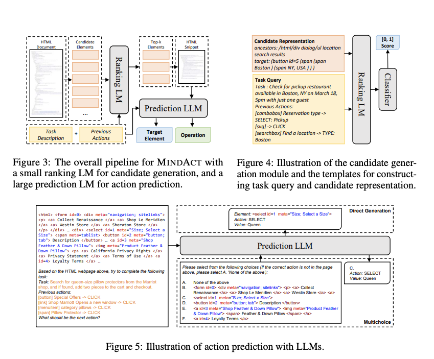

[Deng, Xiang, Yu Gu, Boyuan Zheng, Shijie Chen, Samuel Stevens, Boshi Wang, Huan Sun, and Yu Su. “Mind2Web: Towards a Generalist Agent for the Web.” arXiv, June 14, 2023. http://arxiv.org/abs/2306.06070.](http://arxiv.org/abs/2306.06070)

## Activity Specific Agents: Visual Agents

[figure not shown]

[“Autonomous Visual Information Seeking with Large Language Models,” Google AI Blog,August 18, 2023. https://ai.googleblog.com/2023/08/autonomous-visual-information-seeking.html.](https://ai.googleblog.com/2023/08/autonomous-visual-information-seeking.html)

## Visual Agents Architecture: Different LLMs based on Role

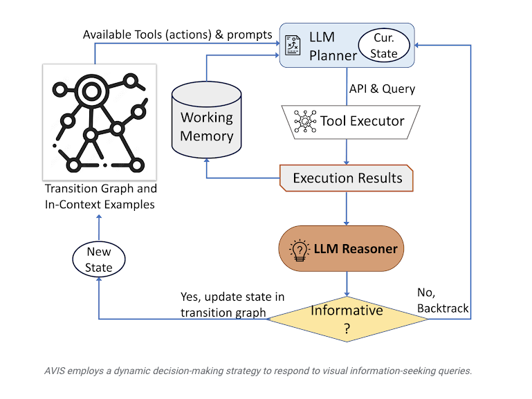

[“Autonomous Visual Information Seeking with Large Language Models,” Google AI Blog,August 18, 2023. https://ai.googleblog.com/2023/08/autonomous-visual-information-seeking.html.](https://ai.googleblog.com/2023/08/autonomous-visual-information-seeking.html)

## Activity Specific Agents: Visual Agents Transition Graph

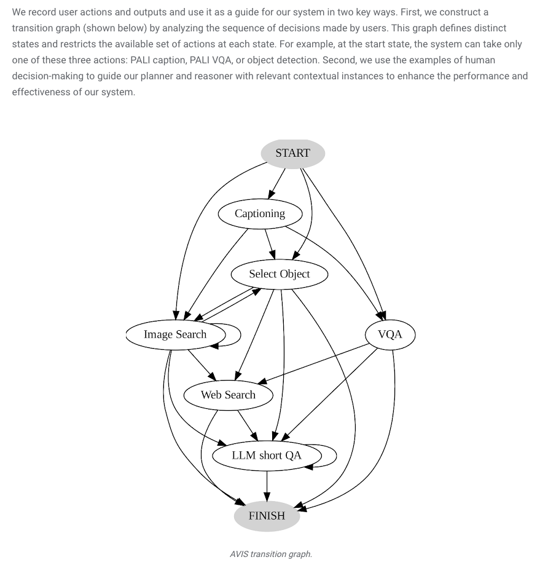

[“Autonomous Visual Information Seeking with Large Language Models,” Google AI Blog,August 18, 2023. https://ai.googleblog.com/2023/08/autonomous-visual-information-seeking.html.](https://ai.googleblog.com/2023/08/autonomous-visual-information-seeking.html)

## Aside: Transformer Vision and segmentation models

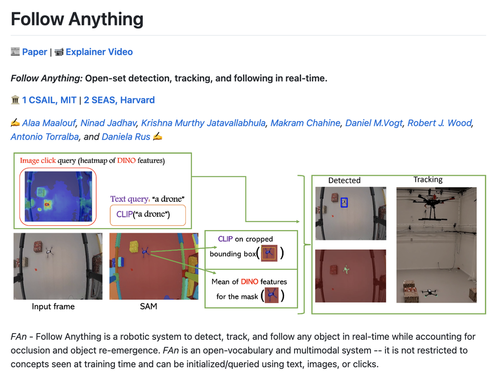

[“Alaamaalouf/FollowAnything.” Accessed August 22, 2023. https://github.com/alaamaalouf/FollowAnything.](https://github.com/alaamaalouf/FollowAnything)

[Maalouf, Alaa, Ninad Jadhav, Krishna Murthy Jatavallabhula, Makram Chahine, Daniel M. Vogt, Robert J. Wood, Antonio Torralba, and Daniela Rus. “Follow Anything: Open-Set Detection, Tracking, and Following in Real-Time.” arXiv, August 10, 2023. https://doi.org/10.48550/arXiv.2308.05737.](https://doi.org/10.48550/arXiv.2308.05737)

## Graphs as a Prompt Structure

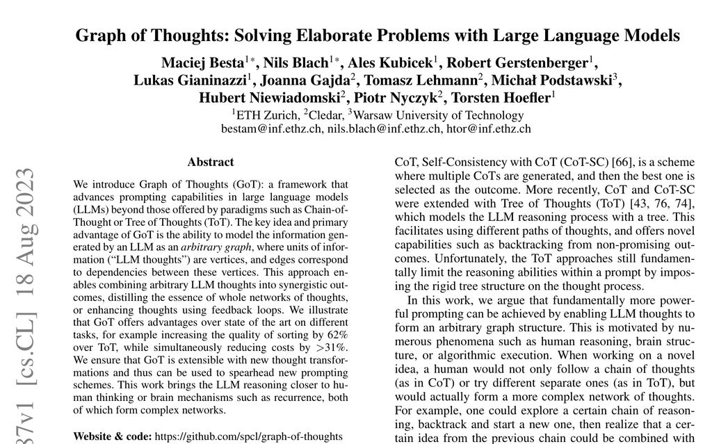

[Besta, Maciej, Nils Blach, Ales Kubicek, Robert Gerstenberger, Lukas Gianinazzi, Joanna Gajda, Tomasz Lehmann, et al. “Graph of Thoughts: Solving Elaborate Problems with Large Language Models.” arXiv, August 21, 2023. http://arxiv.org/abs/2308.09687.](http://arxiv.org/abs/2308.09687)

## Graphs as a Prompt Structure

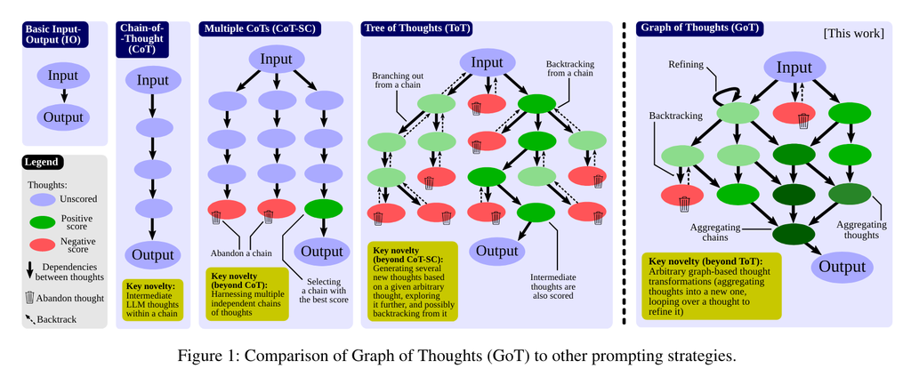

[Besta, Maciej, Nils Blach, Ales Kubicek, Robert Gerstenberger, Lukas Gianinazzi, Joanna Gajda, Tomasz Lehmann, et al. “Graph of Thoughts: Solving Elaborate Problems with Large Language Models.” arXiv, August 21, 2023. http://arxiv.org/abs/2308.09687.](http://arxiv.org/abs/2308.09687)

## Graphs as a Prompt Structure

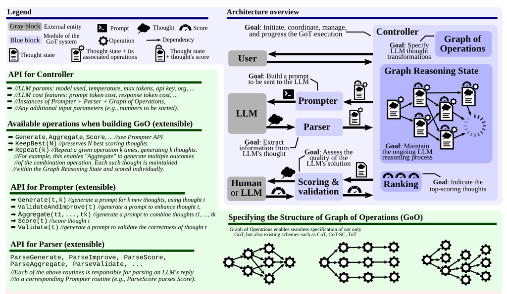

[Besta, Maciej, Nils Blach, Ales Kubicek, Robert Gerstenberger, Lukas Gianinazzi, Joanna Gajda, Tomasz Lehmann, et al. “Graph of Thoughts: Solving Elaborate Problems with Large Language Models.” arXiv, August 21, 2023. http://arxiv.org/abs/2308.09687.](http://arxiv.org/abs/2308.09687)

## Aside: Prompt Engineering Guide

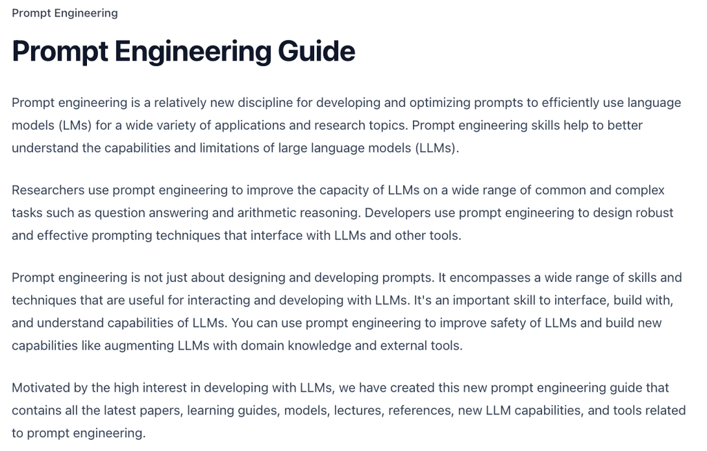

[“Prompt Engineering Guide.” Accessed August 22, 2023. https://www.promptingguide.ai/.](https://www.promptingguide.ai/)

## APIs as Tools: Gorilla

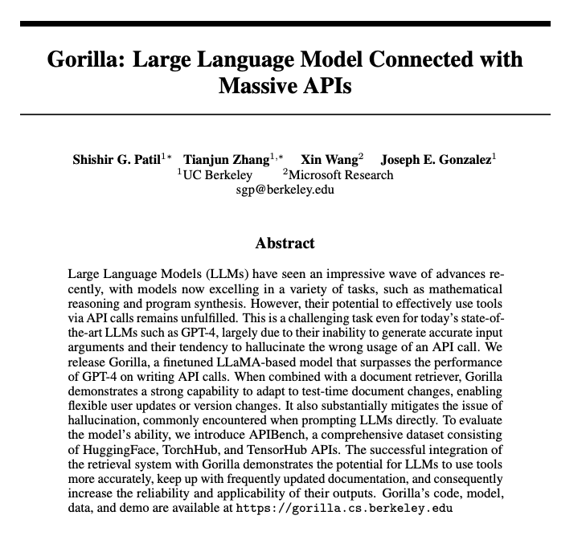

[Patil, Shishir G., Tianjun Zhang, Xin Wang, and Joseph E. Gonzalez. “Gorilla: Large Language Model Connected with Massive APIs.” arXiv, May 24, 2023. http://arxiv.org/abs/2305.15334.](http://arxiv.org/abs/2305.15334)

## APIs as Tools: Architecture

[figure not shown]

[Patil, Shishir G., Tianjun Zhang, Xin Wang, and Joseph E. Gonzalez. “Gorilla: Large Language Model Connected with Massive APIs.” arXiv, May 24, 2023. http://arxiv.org/abs/2305.15334.](http://arxiv.org/abs/2305.15334)

## APIs as Tools

[figure not shown]

[Patil, Shishir. “Gorilla: Large Language Model Connected with Massive APIs [Project Website].” Python, August 22, 2023. https://github.com/ShishirPatil/gorilla.](https://github.com/ShishirPatil/gorilla)

## LLM Personality Traits

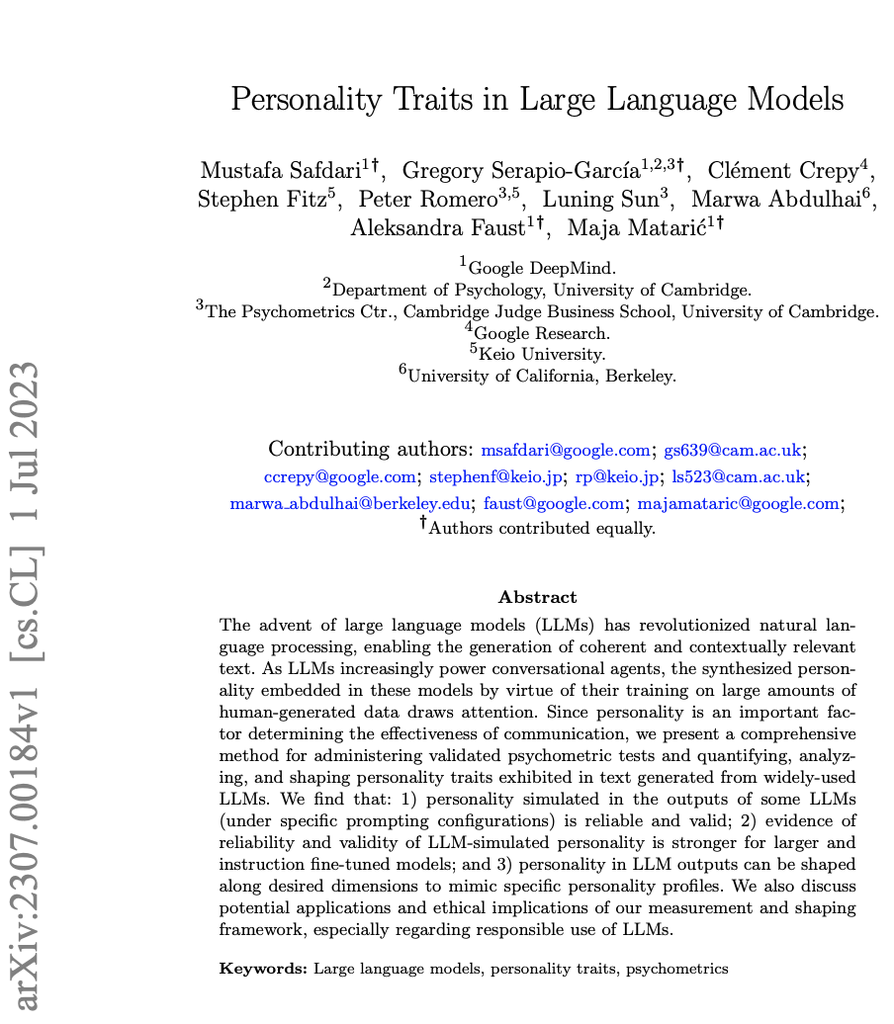

[Safdari, Mustafa, Greg Serapio-García, Clément Crepy, Stephen Fitz, Peter Romero, Luning Sun, Marwa Abdulhai, Aleksandra Faust, and Maja Matarić. “Personality Traits in Large Language Models.” arXiv, June 30, 2023. http://arxiv.org/abs/2307.00184.](http://arxiv.org/abs/2307.00184)

## Using Personality Tests

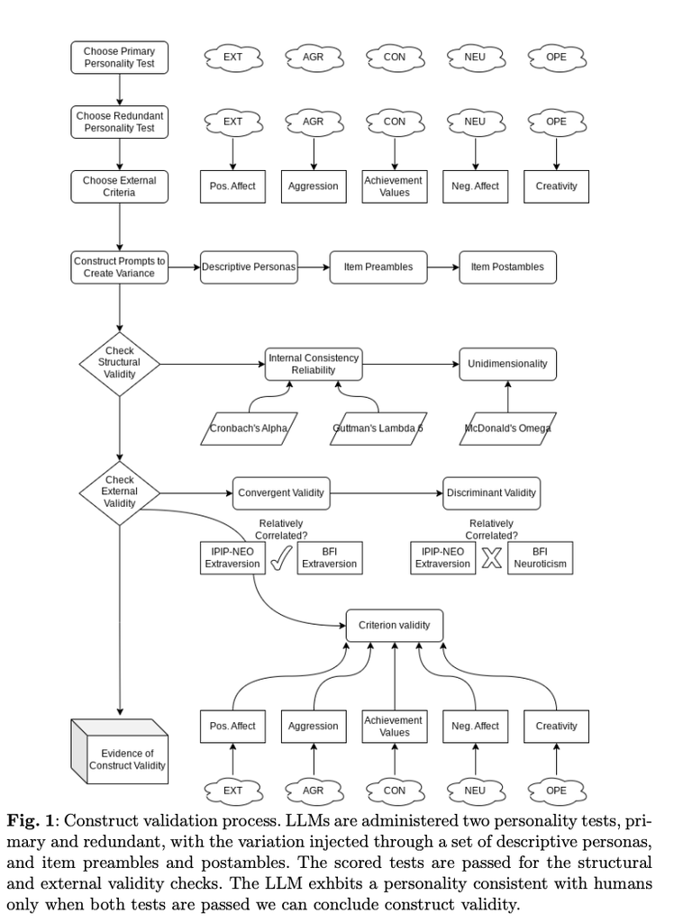

[Safdari, Mustafa, Greg Serapio-García, Clément Crepy, Stephen Fitz, Peter Romero, Luning Sun, Marwa Abdulhai, Aleksandra Faust, and Maja Matarić. “Personality Traits in Large Language Models.” arXiv, June 30, 2023. http://arxiv.org/abs/2307.00184.](http://arxiv.org/abs/2307.00184)

## Behavior Persona Through Prompting

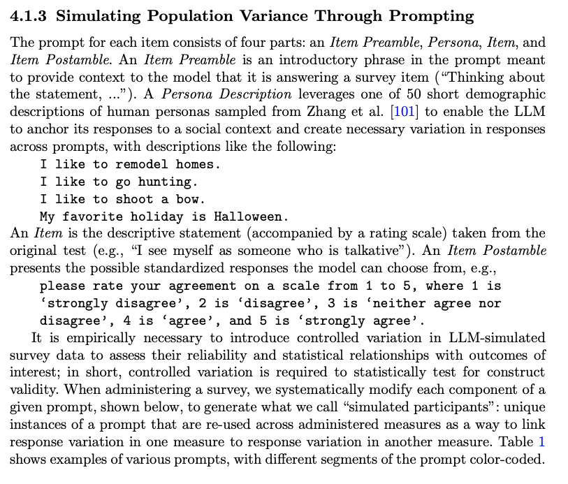

[Safdari, Mustafa, Greg Serapio-García, Clément Crepy, Stephen Fitz, Peter Romero, Luning Sun, Marwa Abdulhai, Aleksandra Faust, and Maja Matarić. “Personality Traits in Large Language Models.” arXiv, June 30, 2023. http://arxiv.org/abs/2307.00184.](http://arxiv.org/abs/2307.00184)

## LLM Personality Traits Malleability

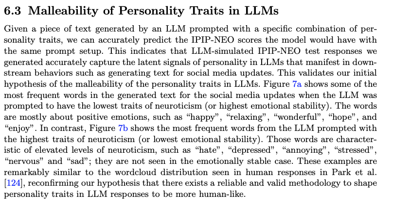

[Safdari, Mustafa, Greg Serapio-García, Clément Crepy, Stephen Fitz, Peter Romero, Luning Sun, Marwa Abdulhai, Aleksandra Faust, and Maja Matarić. “Personality Traits in Large Language Models.” arXiv, June 30, 2023. http://arxiv.org/abs/2307.00184.](http://arxiv.org/abs/2307.00184)

## Grounding Through Hybrid KGs

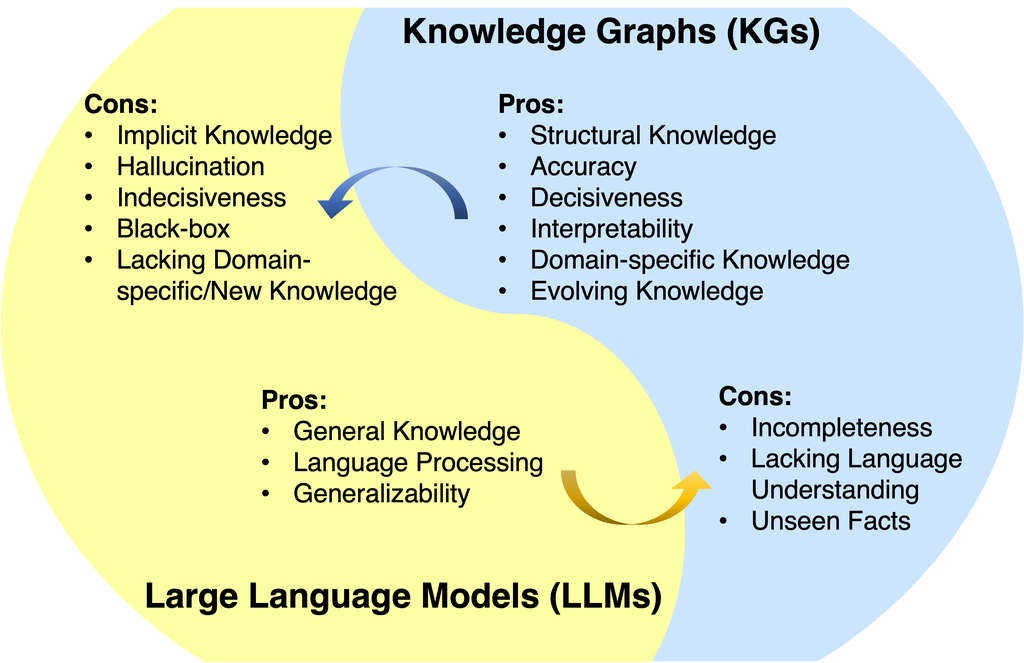

[Shirui Pan, Linhao Luo, Yufei Wang, Chen Chen, Jiapu Wang, and Xindong Wu. “Unifying Large Language Models and Knowledge Graphs: A Roadmap.” arXiv, June 14, 2023. http://arxiv.org/abs/2306.08302.](http://arxiv.org/abs/2306.08302)

## LlamaIndex to Build Hybrid KGs

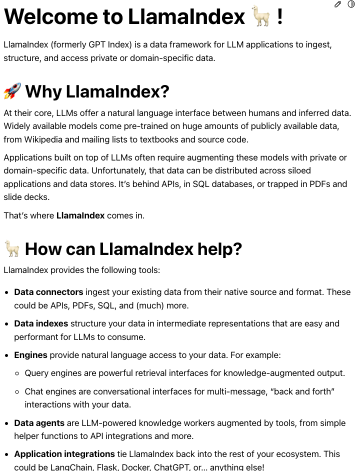

[Liu, Jerry. “LlamaIndex.” Python, November 2022. https://doi.org/10.5281/zenodo.1234.](https://github.com/jerryjliu/llama_index)

## LlamaIndex to Build Hybrid KGs

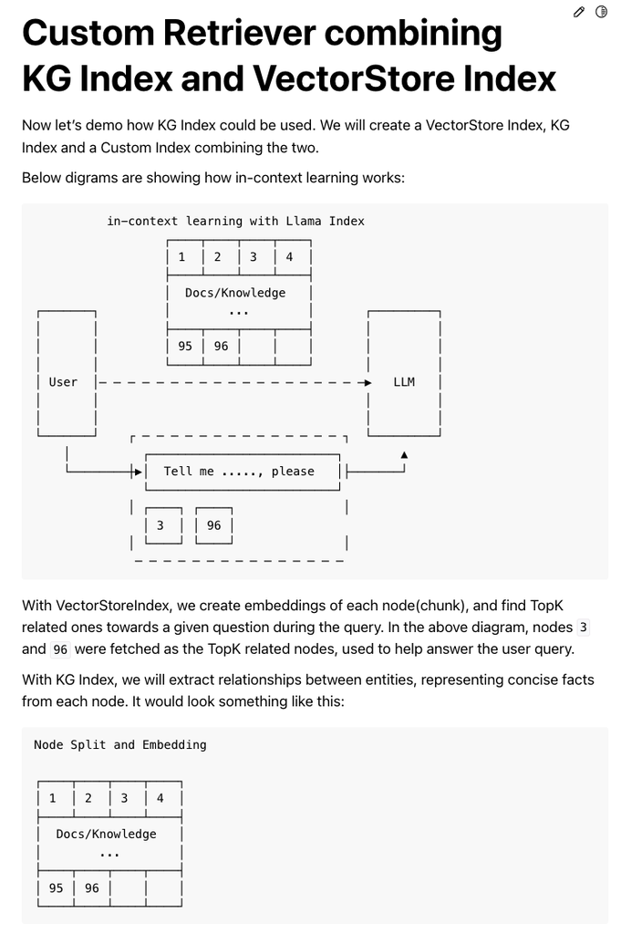

[“Custom Retriever Combining KG Index and VectorStore Index - LlamaIndex 🦙 0.8.5.Post2.” Accessed August 22, 2023. https://gpt-index.readthedocs.io/en/stable/examples/index_structs/knowledge_graph/KnowledgeGraphIndex_vs_VectorStoreIndex_vs_CustomIndex_combined.html.](https://gpt-index.readthedocs.io/en/stable/examples/index_structs/knowledge_graph/KnowledgeGraphIndex_vs_VectorStoreIndex_vs_CustomIndex_combined.html)

## Data Agents in LlamaIndex

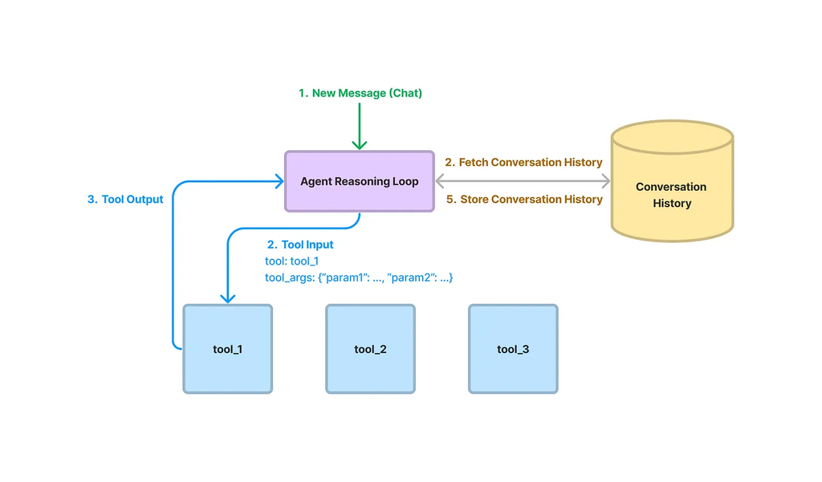

From: [Liu, Jerry. “Data Agents.” LlamaIndex Blog (blog), July 13, 2023. https://medium.com/llamaindex-blog/data-agents-eed797d7972f.](https://medium.com/llamaindex-blog/data-agents-eed797d7972f)